# Math 189/289 Lab 3

Alex Hanbo Li

# Central Limit Theorem

The message of the central limit theorem is that if the sample size is large, then the probability distribution of the sample average is often well approximated by the normal curve (please see page 37 of the slides).

The formal statement is as the following. If $X_1, \cdots, X_n$ are independent, identically distributed with mean $\mu$ and variance $\sigma^2$, then for large $n$, the probability distribution of
$$Z = \frac{\bar X - \mu}{\sigma/\sqrt{n}}$$
is approximately $\mathcal{N}(0, 1)$.

```r
?lwd
```

```
No documentation for ‘lwd’ in specified packages and libraries:
you could try ‘??lwd’
```

```r
?clt
```

```
No documentation for ‘clt’ in specified packages and libraries:
you could try ‘??clt’
```

# Confidence Interval

We are going to work with some simulated data. We generate $N$ numbers from bernoulli distribution with success rate 0.3, and take them as our population.

```r
N <- 1000
data.population <- rbinom(n=N, size=1, prob=0.3)
```

One can give a story line to this data. If put in the same context as the video games dataset that we have for homework, for example, this could be the response of the students in the whole school whether they played games in the past week or not. Thus, the school has 1000 students in total. 1 indicates the student played, and 0 indicates did not play.

Then in that sense, we might not have observed every one of these responses as in for the survey data in the video games dataset. Thus, we sample, say $n$, observations from the population, and take them as our sample units.

```r
n <- 300
ind.sample <- sample.int(n=N, size=n)
data.sample <- data.population[ind.sample]
```

## Sample Statistics

Now we will stick with the story line. Once we have the sample data, we can compute a point estimate, as well as an interval estimate for the fraction of the students who played games in the past week or not.

A point estimate in this case is just the mean of the sample,

```r
mean.sample <- mean(data.sample)
mean.sample
```

```
[1] 0.3333333
```

## A Simple Confidence Interval

As the first example of a confidence interval in the slides, an unrefined 95% confidence interval can be
$$\left(\bar x - 2 \frac{s}{\sqrt{n}}, \bar x + 2 \frac{s}{\sqrt{n}} \right),$$
where $s$ is the sample standard deviation. Note that this simple confidence interval ignores the finite sample population correction factor.

```r
int.simple
```

[output not shown]

```
[1] 0.2788093 0.3878574
```

## Finite Sample Population Correction

To get an interval estimate for the fraction, we follow the derivation in the lecture slides, the interval estimate is then given by,
$$\left(\bar x - 1.96 \sqrt{\frac{\bar x (1 - \bar x)}{n-1} \frac{N - n}{N}}, \bar x + 1.96 \sqrt{\frac{\bar x (1 - \bar x)}{n-1} \frac{N - n}{N}} \right),$$
where $\bar x$ indicates the sample mean, $N$ indicates the population size, and $n$ indicates the sample size. Thus, an interval estimate is then given as the following.

```r
width <- 1.96 * sqrt(mean.sample*(1-mean.sample)*(N-n)/((n-1)*N))
int.exact <- c(mean.sample - width, mean.sample + width)
int.exact
```

```
[1] 0.2886276 0.3780391
```

# Sampling and Bootstrap

## Sampling

Sampling (with or without replacement) can be done in R using the function `sample()`.

```r
sample(1:10, size = 10, replace = F)
```

```
 [1]  6  4  1  7  3  2  8  9 10  5
```

```r
sample(1:10, size = 10, replace = T)
```

```
 [1]  9  3 10  6  8  1  9  7  1  7
```

## Bootstrap

Suppose we want to find the point estimate of the proportion of male in the population and its confidence interval. Note that the *sex* variable is 1 if the student is male and 0 if female. Then the point estimation of the proportion of male is:

```r
data <- read.table("../Case Study 2/videodata.txt", header=TRUE)
male.percentage <- mean(data$sex)
male.percentage
```

```
[1] 0.5824176
```

Now we also want to have a confidence interval of this estimator. However, clearly the distribution of *sex* variable is not Normal, it is a Bernoulli random variable. We know our data were drawn from a population with size $N = 314$. Hence, we first create a bootstrap population of this size by repeating every sample for $\frac{314}{91} = 3.45$ times. Here, we’ll just specify the parameter *length.out* to be 314.

```r
boot.population <- rep(data$sex, length.out = 314)
length(boot.population)
```

```
[1] 314
```

Then we will choose $n = 91$ samples from the Bootstrap population and call this a Bootstrap sample.

```r
sample1 <- sample(boot.population, size = 91, replace = FALSE)
```

Continue this procedure until we have 400 Bootstrap samples.

```r
set.seed(189289)
B = 400 # the number of bootstrap samples we want
boot.sample <- array(dim = c(B, 91))
for (i in 1:B) {
  boot.sample[i, ] <- sample(boot.population, size = 91, replace = FALSE)
}
```

Then we can calculate the sample mean for each Bootstrap sample (i.e. each row of the Bootstrap sample matrix).

```r
boot.mean <- apply(X = boot.sample, MARGIN = 1, FUN = mean)
head(boot.mean)
```

```
[1] 0.5054945 0.6153846 0.6263736 0.6043956 0.4835165 0.5824176
```

Let’s see the histogram of these Bootstrap sample means.

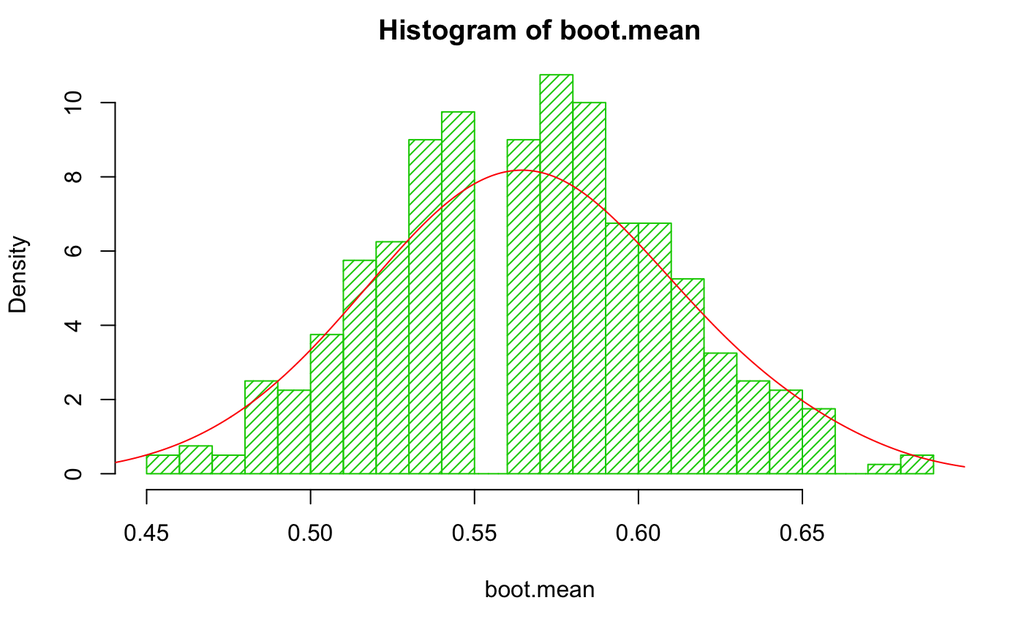

```r
hist(boot.mean, breaks = 20, probability = TRUE, density = 20, col = 3, border = 3)
lines(density(boot.mean, adjust = 2), col = 2)
```

## Bootstrap Confidence Interval

The third and last type of confidence interval we introduce is done with the help of bootstrap. Recall that previously, we have $B=400$ bootstrap sample means. We can build a bootstrap confidence interval by extracting the 0.025-quantile and 0.975 quantile of the bootstrap sample means and arrive at an interval estimate.

```r
int.boot <- c(quantile(boot.mean, 0.025), quantile(boot.mean, 0.975))
int.boot
```

```
     2.5%     97.5%
0.4835165 0.6486264
```